# 스크립트 프로그래밍 과제 3 (10_30일)

### 문제 1번

- L=[1, 2, 3, 4, 5]일 때 다음 각 문장을 수행한 후의 결과를 보고 납득할 만한 이유를 설명하시오.

1)

```python
L=[1, 2, 3, 4, 5]
L[1:3] = [100]
print(L)
```

```
[1, 100, 4, 5]
```

앞부분은 리스트 L의 1번째부터 3번째의 전까지, 즉 L[1] 과 L[2]를 슬라이싱 한 문장이다. 해당 범위를 잡고 이를 다시 100 원소 하나가 들어있는 리스트 [100]을 대입연산으로 추가하였다. 때문에 기존 원소들이 사라지고 그 자리에 100 숫자가 들어간 것을 확인할 수 있다.

2)

```python
L=[1, 2, 3, 4, 5]
L[1:3] = [(100)]
print(L)
```

```
[1, 100, 4, 5]
```

동일하게 L의 원소 두개를 슬라이싱하고 이 대신 패킹된 100이라는 숫자 하나를 대신 넣어준다. 리스트 안의 튜플 '100'은 대입연산 과정에서 언패킹되어 튜플의 형태는 사라진것을 print(L) 구문을 통해 알 수 있다.

3)

```python
L=[1, 2, 3, 4, 5]
L[1:3] = 100
print(L)
```

```
---------------------------------------------------------------------------
TypeError                                 Traceback (most recent call last)
<ipython-input-17-d0274ea64f39> in <module>()
      1 L=[1, 2, 3, 4, 5]
----> 2 L[1:3] = 100
      3 print(L)

TypeError: can only assign an iterable
```

자료가 어떤 형태로도 지정되있지 않다면, 파이썬에서는 기본적으로 튜플로 처리한다.

즉 L[1:3] = (100) 이 되는데, 슬라이싱 된 원소는 두개이기 때문에 리스트 형식이 아니라면 언패킹을 위해 자료의 갯수를 파악한다. 하지만 100은 나눌 수 없는 하나의 원소이고 두개의 원소에 각각 대입할 수 없으므로 에러가 발생한다.

4)

```python
L=[1, 2, 3, 4, 5]
L[1:3] = (100)
print(L)
```

```
---------------------------------------------------------------------------
TypeError                                 Traceback (most recent call last)
<ipython-input-18-f155c5a8ccd1> in <module>()
      1 L=[1, 2, 3, 4, 5]
----> 2 L[1:3] = (100)
      3 print(L)

TypeError: can only assign an iterable
```

바로 위 문제와 동일하게 100은 단일 원소를 가진 튜플로, 원소를 나눌 수 없으므로 에러가 발생한다.

5)

```python
L=[1, 2, 3, 4, 5]
L[1:3] = (100, 101, 102)
print(L)
```

```
[1, 100, 101, 102, 4, 5]
```

6)

```python
L=[1, 2, 3, 4, 5]
L[1:3] = [100, 101, 102]
print(L)
```

```
[1, 100, 101, 102, 4, 5]
```

7)

```python
L=[1, 2, 3, 4, 5]
L[1:3] = [(100, 101, 102)]
print(L)
```

```
[1, (100, 101, 102), 4, 5]
```

맨 바깥쪽의 자료 형태가 리스트이면, 원소의 갯수 상관없이 추가/제거가 가능하므로, 리스트 안의 튜플에 대해 언패킹이 실행되지않고 한개의 튜플 원소로 추가된 것을 알 수 있다.

8)

```python
L=[1, 2, 3, 4, 5]
L[1:3] = [[100, 101, 102]]
print(L)
```

```
[1, [100, 101, 102], 4, 5]
```

위와 같이 맨 바깥쪽이 리스트일 경우 언패킹이 실행되지 않기 때문에 인덱스 L[1]부터 2까지가 제거되고 그 자리에 하나의 리스트 원소가 추가된 것으로 볼 수 있다.

### 문제 2번

- 문자열 S = 'Hello World and Python'에 대해 다음 요구사항에 대한 Python 코드를 제시하시오.
  1. 단어의 순서가 역순으로 되어진 문자열 ('Python and World Hello')을 만들고
  2. 1)의 결과 문자열에 대해 메소드 split과 join을 이용하여 공백을 모두 없엔 문자열 'PythonandWorldHello'을 만드시오.

```python
S =  'Hello World and Python'

S1 = S.split()
reverse = ''
reverse = ' '.join(reversed(S1))
print("1번 결과: " + reverse)
reverse = reverse.split()
S2 = ''.join(reverse)
print("2번 결과: " + S2)
```

```
1번 결과: Python and World Hello
2번 결과: PythonandWorldHello
```

매개변수 사용 없이 split을 쓰면 공백을 기준으로 단어들을 나누고 이를 리스트로 반환한다.

각 단어를 한칸씩 띄워 하나의 역순 문자열로 만들어야 하므로 join 함수의 앞에 구분자로 공백을 넣어주고 reversed라는 규칙을 적용시켜 1)의 문장을 만든다.

이 문자열을 다시 split으로 나누고 이번에는 구분자 없이 join을 사용하면 공백이 모두 사라지고 각 단어들이 붙어서 2) 결과가 반환되는것을 확인 할 수 있다.

### 문제 3번

- 다음 코드를 보고 물음에 답하시오.

```
a = [1, 2, 3]
b = a * 3
c = [a] * 3
print(b)
print(c)
```

1. 위 코드를 수행한 이후 다음 코드를 수행한 후 b와 c의 내용을 확인하시오.

   ```
    a[0]=0
   ```

2. b와 c 객체의 차이는 무엇인가?

```python
a = [1, 2, 3]
b = a * 3
c = [a] * 3
print(b)
print(c)
```

```
[1, 2, 3, 1, 2, 3, 1, 2, 3]
[[1, 2, 3], [1, 2, 3], [1, 2, 3]]
```

1) 위 코드를 수행한 이후 다음 코드를 수행한 후 b와 c의 내용을 확인하시오.

```python
a[0] = 0
print (b)
print (c)
```

```
[1, 2, 3, 1, 2, 3, 1, 2, 3]
[[0, 2, 3], [0, 2, 3], [0, 2, 3]]
```

2) b와 c 객체의 차이는 무엇인가?

> b는 연산의 대상인 a 리스트의 원소의 '값'들을 세번 복사하여 새로운 리스트 b를 생성한 것이다.

> 반면에 c는 []괄호를 통해 'a 리스트의 주소값'을 그대로 가져와 3개의 원소로 갖는 리스트로 생성되었다.

> 때문에 c의 경우 a리스트의 값을 변경하면 변경된 a 리스트를 그대로 보여주는것을 확인 할 수 있다.

### 문제 4번

- 다음 문자열을 ':'을 기준으로 분리하여 리스트로 만들고 각 문자열의 좌우 공백을 제거하시오 (즉, 문자열 S에서 l을 만들어라)

  s = ' first star : second star : third star '

  l = ['first star', 'second star', 'third star']
  1. for ~ in 문을 이용한 코드를 작성하시오.
  2. 리스트 내포(list comprehension)를 이용한 코드를 작성하시오.

```python
s = ' first star : second star : third star '
l = []
s = s.split(':')
for i in range(len(s)):
    l.append( s[i].strip() )

print (l)
```

```
['first star', 'second star', 'third star']
```

2) 리스트 내포(list comprehension)를 이용한 코드를 작성하시오.

```python
s = ' first star : second star : third star '
l = [s.split(':')[i].strip() for i in range(3)]
print (l)
```

```
['first star', 'second star', 'third star']
```

### 문제 5

- 다음과 같이 0보다 큰 정수 리스트 변수 list를 인자로 받는 함수 addall(list)와 addallodd(list)를 for ~ in 리터널과 리스트 내포 방식으로 각각 제시하시오.
1. addall(list) 함수 (리스트 내의 모든 정수를 더하는 함수로서 해답으로는 for ~ in 리터럴과 리스트 내포 방식으로 각각 제시하시오.)
2. addallodd(list) 함수 (리스트내의 모든 홀수를 더하는 함수로서 해답으로는 for ~ in 리터럴과 리스트 내포 방식으로 각각 제시하시오.)
- [참고 1]: 리스트 내포 방식으로 addall() 및 addallodd()함수를 만들 때엔 리스트 내포에 의해 생성된 리스트 결과에 대해 내장 함수를 사용하는 방식을 고려해보시오 (주의: 리스트 내포 방식의 addall() 및 addallodd() 함수의 몸체는 단 1줄로 작성되어야 한다.)
- [참고 2]: sum() 등의 내장함수 사용 가능함

1) addall(list) 함수 (리스트 내의 모든 정수를 더하는 함수로서 해답으로는 for ~ in 리터럴과 리스트 내포 방식으로 각각 제시하시오.)

```python
#for ~ in
def addall(l):
    x = 0
    for i in range(len(l)):
        x += l[i]
    print (x)

addall([1,2,3,4,5,6,7,8,9,10])

#리스트 내포 방식
def addall(l):
    print (sum([i for i in l]))

addall([1,2,3,4,5,6,7,8,9,10])
```

```
55
55
```

2) addallodd(list) 함수 (리스트내의 모든 홀수를 더하는 함수로서 해답으로는 for ~ in 리터럴과 리스트 내포 방식으로 각각 제시하시오.)

```python
#for ~ in
def addallodd(l):
    x = 0
    for i in range(len(l)):
        if(l[i]%2 == 1):
            x += l[i]
    print (x)

addallodd([1,2,3,4,5,6,7,8,9,10])

#리스트 내포 방식
def addallodd(l):
    print (sum([x for x in l if x%2 == 1]))

addallodd([1,2,3,4,5,6,7,8,9,10])
```

```
25
25
```

### 문제 6

- 다음 코드를 보고 물음에 답하시오.

```python
L1 = [1, 2, 3]
L2 = [4, 5, 6]
d = {'low':L1, 'high':L2}
e = d
f = d.copy()
print(d)
print(e)
print(f)
print()
d['low'] = [10, 20, 30]
d['high'][1] = 500
print(d)
print(e)
print(f)
```

```
{'low': [1, 2, 3], 'high': [4, 5, 6]}
{'low': [1, 2, 3], 'high': [4, 5, 6]}
{'low': [1, 2, 3], 'high': [4, 5, 6]}

{'low': [10, 20, 30], 'high': [4, 500, 6]}
{'low': [10, 20, 30], 'high': [4, 500, 6]}
{'low': [1, 2, 3], 'high': [4, 500, 6]}
```

1) 위 코드의 수행 결과 d와 e는 항상 같은 결과를 출력한다. 그 이유는 무엇인가?

> 위 코드에서 e는 대입연산으로 d의 값을 복사하였다. 이는 d라는 문자가 가리키는 객체의 주소값을 가져와 그대로 e에 넣어준 것이다. 결국 d와 e가 동일한 객체를 가리키므로 그 출력값 또한 항상 같다.

2) 위 코드의 수행 결과 마지막 f의 내용은 다음과 같다. 이 때 'high' 키의 값 내용 중 500이 출력된 이유와 'low' 키의 값 내용 중 [1, 2, 3]이 출력된 이유를 설명하시오 ([hint]: shallow copy 관점에서 설명하시오.)

```
{'high': [4, 500, 6], 'low': [1, 2, 3]}
```

> f는 d 사전을 copy() 메소드를 사용해 복사해온 객체이다. 때문에 f는 데이터를 추출해 새로운 문자열을 만드는 깊은 복사(deep copy)가 아닌 d 사전에서 키값과 가리키는 문자열의 주소만 복사하는 얕은 복사(shallow copy)의 결과값이다.

> 때문에 키값에 연결된 주소를 바꿔주지 않는 한, L1과 L2가 바뀌면 f의 결과값 또한 같이 바뀌게 된다.

```
        d['low'] = [10, 20, 30]
        d['high'][1] = 500
```

> 두 문장에서 d['low'] 에 대해 리스트를 대입한 연산은 사전d의 키값 'low'에 대응하는 주소를 바꿔주는 연산이다. 때문에 이미 주소를 복사해온 f에 대해서는 영향을 주지 않는다.

> 하지만 d['high'][1] = 500 문장은 d['high'] 의 결과값인 L2문자열에 대해 [1] 인덱싱 값을 바꿔주는 문장이므로 결과적으로는 문자열 L2의 원소를 바꾸는 것이다. 때문에 f를 출력하면 바뀐 원소값을 확인 할 수 있다.

### 문제 7

- 사전 d = {'one':1, 'two':2, 'three':3, 'four':4, 'five':5}가 주어졌을 때 다음 요구사항에 맞는 코드를 제시하시오
  - [참고]: d.keys(), d.values()를 통해 리스트를 얻어낸 후 리스트가 지니고 있는 sort(cmp=None, key=None, reverse=False)함수를 활용하시오.
  - 1) 키의 알파벳 오름차순 순서대로 튜플 (키, 값)을 차례대로 출력하시오.
  - 2) 키의 알파벳 내림차순 순서대로 튜플 (키, 값)을 차례대로 출력하시오.
  - 3) 값의 오름차순 순서대로 튜플 (키, 값)을 차례대로 출력하시오.
  - 4) 값의 내림차순 순서대로 튜플 (키, 값)을 차례대로 출력하시오.

```python
d = {'one':1, 'two':2, 'three':3, 'four':4, 'five':5}
dkey = []
for key in d.keys():
    dkey.append(key)
dvalue = []
for key in d.values():
    dvalue.append(key)
dprint = []

for i in range(len(dkey)):
    dprint.append((dkey[i],dvalue[i]))

dprint.sort()
# 1)번 출력값
print (dprint)

dprint.sort(reverse=True)
# 2)번 출력값
print (dprint)

def cmp_by_1_element(a):
    return a[1]
dprint.sort(key=cmp_by_1_element)
# 3)번 출력값
print (dprint)

dprint.sort(key=cmp_by_1_element,reverse=True)
# 4)번 출력값
print (dprint)
```

```
[('five', 5), ('four', 4), ('one', 1), ('three', 3), ('two', 2)]
[('two', 2), ('three', 3), ('one', 1), ('four', 4), ('five', 5)]
[('one', 1), ('two', 2), ('three', 3), ('four', 4), ('five', 5)]
[('five', 5), ('four', 4), ('three', 3), ('two', 2), ('one', 1)]
```

### 문제 8

- [ACM-ICPC 문제 1152번]
  - 단어의 개수
    - 영어 대소문자와 띄어쓰기만으로 이루어진 문장이 주어진다. 이 문장에는 몇 개의 단어가 있을까? 이를 구하는 프로그램을 작성하시오. 단, 단어는 띄어쓰기 하나로 구분된다고 생각한다.
    - 첫 줄에 영어 대소문자와 띄어쓰기로 이루어진 문장이 주어진다. 이 문장의 길이는 1,000,000을 넘지 않는다.
    - 첫째 줄에 단어의 개수를 출력한다.

```python
cal = input()
cals = cal.split(' ')
c = 0
for i in cals:
    if (i != ''):
        c +=1
print (c)
```

```
The Curious Case of Benjamin Button
6
```

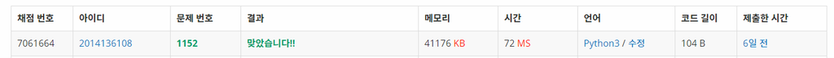

```python
from IPython.display import Image
Image(filename='correct.PNG')
```

공백을 기준으로 나눈 각 단어들을 cals에 리스트로 넣어주고 각 원소들이 공백이 아닐경우 변수 c의 값을 1씩 올려 카운트 한 다음 이를 출력한다.

### 문제 9

- [Incremental Project] 이전 Assignment 2의 마지막 문제는 웹 URL로 지정된 웹페이지를 문자열로 가져와 모든 HTML 태그 및 CSS와 Javascript를 제외한 순수 텍스트를 얻어내고 그 안에 존재하는 단어를 추출하고 단어들의 총 개수를 출력하는 프로그램을 작성하는 것이었다. 이번에는 그 마지막 숙제를 그대로 확장하여 웹 URL로 지정된 웹페이지 내 순수 텍스트 안에 존재하는 각 단어들에 대해 다음 요구사항 대로 출력하는 프로그램을 작성하시오.
  - 요구사항 1. 순수 텍스트 안에 존재하는 단어들에 대해 string 모듈을 활용하여 모든 punctuation (구두문자)를 완벽히 제거하시오.
    - 예: ['world!', ':', '+hello+', '~python$$$', '=', 'world'] ---> ['world', 'hello', 'python', 'world']
    - 모든 punctuation을 확인하는 방법은 아래와 같다.

      ```
        import string
        print(string.punctuation
      ```

  - 요구사항 2. 만약 punctuation (구두문자)를 제거한 이후 공백으로 판명되는 단어들은 해당 단어 리스트에서 제거하시오.
    - 예: ['컴퓨터공학부!', '---?', '%지향~', '...'] ---> ['컴퓨터공학부', '지향']
  - 요구사항 3. 각 단어들의 출현빈도를 사전형태로 저장하여 출력하시오.
    - 예: ['world', 'hello', 'python', 'world', '컴퓨터공학부', '지향'] ---> {'world': 2, 'hello': 1, 'python': 1, '컴퓨터공학부': 1, '지향': 1}
  - 요구사항 4. 다음 3개의 사이트에 대한 결과를 출력하시오.
    - http://www.naver.com
    - http://www.daum.net
    - http://www.nytimes.com

```python
#페이지로부터 소스를 불러온다.
import string
from urllib import request
url = 'http://www.naver.com'
f = request.urlopen(url)
source_bytes = f.read()
source = source_bytes.decode('utf-8')

#<> 괄호로 쌓인 부분을 제거한다.
state = 1
pull = ''
for i in range(len(source)):
    if (source[i] == '<'):
        state = -1
        continue
    if(source[i] == '>'):
        state = 1
        continue
    if (state == 1):
        pull += source[i]
#pull 을 문자열에서 공백을 제거한 리스트로 변환
pull = pull.split();

#pull 리스트의 원소 문자열들에서 구두문자만 제거 후 다시 대입
for i in range(len(pull)):
    for j in range(len(string.punctuation)):
        pull[i] = pull[i].replace(string.punctuation[j],"")

#pull 리스트 원소들을 단어마다 공백을 넣고 문자열 하나로 묶는다 ('' 제거 위함)
st_pull = ''
for i in range(len(pull)):
    st_pull += (pull[i] + ' ')

#이를 다시 공백 기준으로 나눠 pull에 리스트로 넣어주고 사전 생성
dic_pull = {}
pull = st_pull.split()
for i in pull:
    if not i in dic_pull.keys():
        dic_pull[i]=1
    else:
        dic_pull[i]+=1

print (dic_pull)
```

[output not shown]

```python
#페이지로부터 소스를 불러온다.
import string
from urllib import request
url = 'http://www.daum.net'
f = request.urlopen(url)
source_bytes = f.read()
source = source_bytes.decode('utf-8')

#<> 괄호로 쌓인 부분을 제거한다.
state = 1
pull = ''
for i in range(len(source)):
    if (source[i] == '<'):
        state = -1
        continue
    if(source[i] == '>'):
        state = 1
        continue
    if (state == 1):
        pull += source[i]
#pull 을 문자열에서 공백을 제거한 리스트로 변환
pull = pull.split();

#pull 리스트의 원소 문자열들에서 구두문자만 제거 후 다시 대입
for i in range(len(pull)):
    for j in range(len(string.punctuation)):
        pull[i] = pull[i].replace(string.punctuation[j],"")

#pull 리스트 원소들을 단어마다 공백을 넣고 문자열 하나로 묶는다 ('' 제거 위함)
st_pull = ''
for i in range(len(pull)):
    st_pull += (pull[i] + ' ')

#이를 다시 공백 기준으로 나눠 pull에 리스트로 넣어주고 사전 생성
dic_pull = {}
pull = st_pull.split()
for i in pull:
    if not i in dic_pull.keys():
        dic_pull[i]=1
    else:
        dic_pull[i]+=1

print (dic_pull)
```

[output not shown]

```python
#페이지로부터 소스를 불러온다.
import string
from urllib import request
url = 'http://www.nytimes.com'
f = request.urlopen(url)
source_bytes = f.read()
source = source_bytes.decode('utf-8')

#<> 괄호로 쌓인 부분을 제거한다.
state = 1
pull = ''
for i in range(len(source)):
    if (source[i] == '<'):
        state = -1
        continue
    if(source[i] == '>'):
        state = 1
        continue
    if (state == 1):
        pull += source[i]
#pull 을 문자열에서 공백을 제거한 리스트로 변환
pull = pull.split();

#pull 리스트의 원소 문자열들에서 구두문자만 제거 후 다시 대입
for i in range(len(pull)):
    for j in range(len(string.punctuation)):
        pull[i] = pull[i].replace(string.punctuation[j],"")

#pull 리스트 원소들을 단어마다 공백을 넣고 문자열 하나로 묶는다 ('' 제거 위함)
st_pull = ''
for i in range(len(pull)):
    st_pull += (pull[i] + ' ')

#이를 다시 공백 기준으로 나눠 pull에 리스트로 넣어주고 사전 생성
dic_pull = {}
pull = st_pull.split()
for i in pull:
    if not i in dic_pull.keys():
        dic_pull[i]=1
    else:
        dic_pull[i]+=1

print (dic_pull)
```

[output not shown]

## 이번 과제를 마친 후 소감

마지막 문제를 포함해서 과제를 하는 내내 자료의 메소드를 어떻게 활용해야 할 지 끊임없이 고민하게 하는 문제들이였습니다. 하지만 막히는 부분이 나올 때마다 메소드를 구글링하며 스스로도 많은 공부가 된 것 같았고 좀 더 파이썬을 알아가는 제 모습을 발견할 수 있었습니다. 질문이 있으면 항상 빠르게 답변해주시는 조교님 항상 감사합니다!